# Machine Learning Project

Andrew Woods

30 December 2016

## About the data

Data was collected from 4 participants over 2 hours each performing a particular exercise. The following data was collected, or derived from the acceleromiter readings:

- For each accelerometer: angles of roll and pitch and the length of the acceleration vector.
- Variance of roll, pitch and module of acceleration for all samples.

## Getting and cleaning the data

```r
trainData <- read.csv("https://d396qusza40orc.cloudfront.net/predmachlearn/pml-training.csv", header = TRUE, na.strings = c("", " ", "NA"))
```

Did to length of report constaints exporatory data analysis will not be included in this report.

We can see that most of the data is either NA or blank, so we can remove these columns.

```r
#na_count <-sapply(trainData, function(y) sum(length(which(is.na(y)))))
#na_count <- data.frame(na_count)
#blank_count <-sapply(trainData, function(y) sum(y==""))
#blank_count <- data.frame(blank_count)
trainData <- trainData[,colSums(is.na(trainData)) == 0]
```

Look at correlation to see if we can subset further.

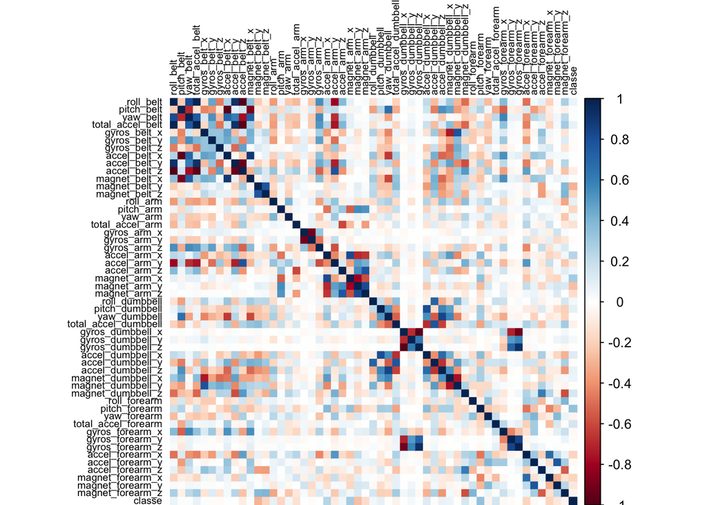

```r
corData <- trainData[,8:60]
corData$classe <- as.numeric(corData$classe)
trainCor <- cor(corData)
corrplot(trainCor, method = "color", tl.col = "black", tl.cex = 0.6)
```

It looks like there is no strong single correlation between classe and any other variable, so we cannot subset further.

```r
summary(trainCor[-53,"classe"])
```

```
##       Min.    1st Qu.     Median       Mean    3rd Qu.       Max.
## -0.2903000 -0.0453500 -0.0002668 -0.0014880  0.0457300  0.3438000
```

Split the data into training and validation sets. Removing the first few columns as the model will pick up the index X as the most important variable.

```r
inTrainging <- createDataPartition(y = trainData$classe, p = 0.5, list = FALSE)
training <- trainData[inTrainging,8:60]
validation <- trainData[-inTrainging,8:60]
```

## cross validation and modelling

Split the training data set into 5, this is included in the random forest method of the train command. Using k-folds as there apears to be some time series element.

```r
set.seed(696969)
#folds <- createFolds(y=trainData$classe, k = 10, list = TRUE, returnTrain = TRUE)
model <- train(classe ~ .,data = training, method = "rf",
                trControl = trainControl(method = "cv", number = 5),
                prox = TRUE, allowParallel = TRUE)
```

## results

```r
varImp(model)
```

```
## rf variable importance
##
##   only 20 most important variables shown (out of 52)
##
##                      Overall
## roll_belt            100.000
## pitch_forearm         57.721
## yaw_belt              46.518
## magnet_dumbbell_z     43.561
## pitch_belt            42.227
## roll_forearm          41.358
## magnet_dumbbell_y     40.333
## accel_dumbbell_y      19.572
## magnet_dumbbell_x     18.396
## accel_forearm_x       18.396
## roll_dumbbell         17.832
## magnet_belt_z         14.567
## accel_dumbbell_z      13.709
## magnet_belt_y         13.603
## magnet_forearm_z      12.663
## accel_belt_z          12.495
## total_accel_dumbbell  11.757
## yaw_arm                9.674
## gyros_belt_z           9.585
## roll_arm               9.232
```

```r
print(model)
```

```
## Random Forest
##
## 9812 samples
##   52 predictor
##    5 classes: 'A', 'B', 'C', 'D', 'E'
##
## No pre-processing
## Resampling: Cross-Validated (5 fold)
## Summary of sample sizes: 7849, 7850, 7850, 7849, 7850
## Resampling results across tuning parameters:
##
##   mtry  Accuracy   Kappa
##    2    0.9844068  0.9802715
##   27    0.9854262  0.9815621
##   52    0.9751330  0.9685375
##
## Accuracy was used to select the optimal model using  the largest value.
## The final value used for the model was mtry = 27.
```

```r
print(model$finalModel)
```

```
##
## Call:
##  randomForest(x = x, y = y, mtry = param$mtry, proximity = TRUE,      allowParallel = TRUE)
##                Type of random forest: classification
##                      Number of trees: 500
## No. of variables tried at each split: 27
##
##         OOB estimate of  error rate: 1.08%
## Confusion matrix:
##      A    B    C    D    E class.error
## A 2785    3    1    0    1 0.001792115
## B   19 1865   14    0    1 0.017904160
## C    0   17 1686    8    0 0.014611338
## D    0    2   25 1579    2 0.018034826
## E    1    1    4    7 1791 0.007206208
```

Lets test the model on the validation set.

```r
predict(model, newdata = validation)
```

[output not shown]

```r
validationTest <- predict(model, newdata = validation)
confusionMatrix(validationTest, validation$classe)
```

```
## Confusion Matrix and Statistics
##
##           Reference
## Prediction    A    B    C    D    E
##          A 2785   23    0    0    0
##          B    4 1850   14    5    3
##          C    0   24 1688   13    4
##          D    0    1    9 1590   15
##          E    1    0    0    0 1781
##
## Overall Statistics
##
##                Accuracy : 0.9882
##                  95% CI : (0.9858, 0.9902)
##     No Information Rate : 0.2844
##     P-Value [Acc > NIR] : < 2.2e-16
##
##                   Kappa : 0.985
##  Mcnemar's Test P-Value : NA
##
## Statistics by Class:
##
##                      Class: A Class: B Class: C Class: D Class: E
## Sensitivity            0.9982   0.9747   0.9866   0.9888   0.9878
## Specificity            0.9967   0.9967   0.9949   0.9970   0.9999
## Pos Pred Value         0.9918   0.9861   0.9763   0.9845   0.9994
## Neg Pred Value         0.9993   0.9940   0.9972   0.9978   0.9973
## Prevalence             0.2844   0.1935   0.1744   0.1639   0.1838
## Detection Rate         0.2839   0.1886   0.1721   0.1621   0.1815
## Detection Prevalence   0.2862   0.1912   0.1762   0.1646   0.1817
## Balanced Accuracy      0.9975   0.9857   0.9907   0.9929   0.9938
```

## predictions

Read in the data for the quiz and run the predictions

```r
testData <- read.csv("https://d396qusza40orc.cloudfront.net/predmachlearn/pml-testing.csv", header = TRUE)
predict(model, newdata = testData)
```

```
##  [1] B A B A A E D B A A B C B A E E A B B B
## Levels: A B C D E
```